# Chapter 7 Exercise Solutions

Keith McNulty

```r
library(rethinking)
```

## ‘Easy’ exercises

### 7E1

Any measure of information entropy should be:

1. **Continuous**, in order to avoid a situation where a miniscule change in the probability of an event would lead to a much larger change in overall uncertainty.
2. **Increasing with the number of possible events**, as intuitively any situation where more things can happen leads to greater overall uncertainty.
3. **Additive**, to ensure that the overall uncertainty around combinations of events are the sum of the overall uncertainties of the individual events.

### 7E2

The entropy of the coin is $-(0.7 \times \ln{0.7}) + 0.3 \times \ln{0.3})$, which equals 0.61

### 7E3

Calculate $H(p)$:

```r
p <- c(0.2, 0.25, 0.25, 0.3)

-sum(p*log(p))
```

```
## [1] 1.376227
```

### 7E4

Remember that events with zero probability have infinite log-probability and should be removed. Calculate $H(q)$:

```r
q <- c(1/3, 1/3, 1/3)

-sum(q*log(q))
```

```
## [1] 1.098612
```

## ‘Medium’ exercises

### 7M1

$\mathrm{AIC} = 2(p - \mathrm{lppd})$ where $\mathrm{lppd}$ is the log-pointwise-predictive-density, defined as

$$\mathrm{lppd} = \Sigma_{i = 1}^{N}\frac{1}{S}\Sigma_{s = 1}^{S}\ln{P(y_i\mid\theta_{-i, s})}$$

using leave-one-out cross validation and where $p$ is the number of free parameters in the posterior distribution.

$\mathrm{WAIC} = 2(\Sigma_{i}\mathrm{var}_{\theta}\ln{p(y_i\mid\theta)} - \mathrm{lppd})$

The $\mathrm{AIC}$ is simpler because it uses the number of free parameters as a penalty term.

$\mathrm{WAIC}$ is more general. $\mathrm{AIC}$ is only reliable when

1. Using flat priors or where priors are overwhelmed by likelihood
2. The posterior distribution is approximately normal
3. The sample size is much greater than the number of parameters

### 7M2

Model selection involves discarding models that do not meet certain information criteria. Model comparison does not discard models but uses comparisons of their information criteria to make conclusions about relative accuracy and the predictive effects of specific variables and can help with causal inference.

### 7M3

This relates to the way $\mathrm{lppd}$ is defined (see 7M1). In a larger sample, more is added to $\mathrm{lppd}$, and since logs of probabilities are negative, this makes $\mathrm{lppd}$ more and more negative. This will decrease $\mathrm{lppd}$ and it will increase measures like $\mathrm{AIC}$, $\mathrm{WAIC}$ and $\mathrm{PSIS}$. Therefore, if you compare two models using different sample sizes, you may be fooled into thinking that one is less predictive just because there is a larger sample, and not necessarily because there is a difference in predictive accuracy.

### 7M4

The effective number of parameters is the first term in the formula for $\mathrm{WAIC}$ as given in 7M1. If a prior becomes more concentrated, then extreme probabilities are less likely to occur in the formula and therefore the variances in the first term will be smaller. This will reduce the $\mathrm{WAIC}$, indicating a reduction in information loss/a more predictive model.

### 7M5

Informative priors are less tolerant of extreme values in the training set when determining model parameters. Therefore the model will not get overexcited by unusual data, and will keep parameters within certain bounds based on the (hopefully) scientific judgement that the priors represent. In theory, this reduces the chance of overfitting.

### 7M6

Overly informative priors will increase the chance that data will be ignored in favor of a very narrow range of plausible parameter values. This will encourage the model towards a fit using less information from the data, which risks underfitting.

## ‘Hard’ exercises

### 7H1

Let’s get the data and fit a straight like and a couple of curved models:

```r
data("Laffer")
d <- Laffer
str(d)
```

```
## 'data.frame':    29 obs. of  2 variables:
##  $ tax_rate   : num  0.07 8.81 12.84 16.24 19.18 ...
##  $ tax_revenue: num  -0.06 2.45 3.58 2.19 2.46 1.95 1.25 1.59 3.37 2.87 ...
```

`tax_rate` looks like it is a percent value, but it’s hard to know what `tax_revenue` is and I’m worried that it may not be adjusted for population size, which could be a big problem. In any case let’s standardize these measures:

```r
library(dplyr)
d <- d |>
  mutate(across(everything(), standardize))
```

OK, now let’s start fitting some models:

```r
# straight line model with vague priors
m1 <- quap(
  alist(
    tax_revenue ~ dnorm(mu, sigma),
    mu <- a + b*tax_rate,
    a ~ dnorm(0, 0.2),
    b ~ dnorm(0, 0.5),
    sigma ~ dexp(1)
  ),
  data = d
)

# quadratic model
m2 <- quap(
  alist(
    tax_revenue ~ dnorm(mu, sigma),
    mu <- a + b[1]*tax_rate + b[2]*tax_rate^2,
    a ~ dnorm(0, 0.2),
    b ~ dnorm(0, 0.5),
    sigma ~ dexp(1)
  ),
  data = d,
  start = list(b = c(0, 0))
)

# cubic model
m3 <- quap(
  alist(
    tax_revenue ~ dnorm(mu, sigma),
    mu <- a + b[1]*tax_rate + b[2]*tax_rate^2 + b[3]*tax_rate^3,
    a ~ dnorm(0, 0.2),
    b ~ dnorm(0, 0.5),
    sigma ~ dexp(1)
  ),
  data = d,
  start = list(b = c(0, 0, 0))
)
```

Let’s compare on WAIC and PSIS:

```r
compare(m1, m2, m3)
```

```
##        WAIC       SE     dWAIC      dSE    pWAIC    weight
## m2 89.18369 24.73776 0.0000000       NA 7.120149 0.4532353
## m1 89.85473 23.35348 0.6710312 2.068940 6.531233 0.3240494
## m3 90.60473 25.83074 1.4210340 1.214096 7.973125 0.2227153
```

```r
compare(m1, m2, m3, func = PSIS)
```

```
##        PSIS       SE    dPSIS      dSE     pPSIS     weight
## m2 92.77268 29.12409 0.000000       NA  8.923748 0.73881295
## m1 95.70220 29.55924 2.929522 1.765323  9.485686 0.17076420
## m3 96.97377 31.11947 4.201096 2.613151 11.095143 0.09042285
```

There doesn’t appear to be a great deal of difference between these models using WAIC or PSIS. However, I did receive a k-value warning from PSI so it looks like there may be some naughty outliers here.

### 7H2

Let’s calculate pointwise WAIC and PSIS and plot them for each model.

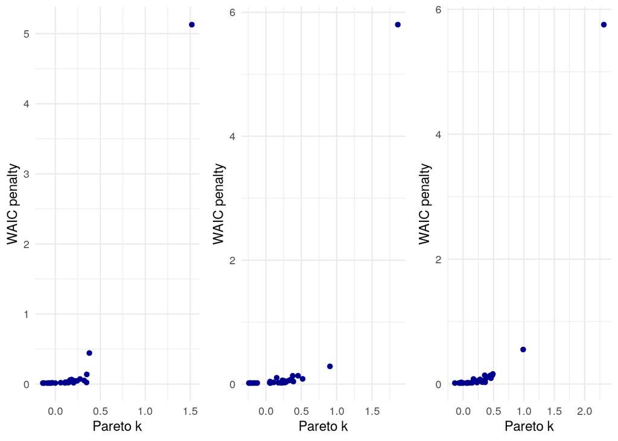

```r
library(ggplot2)

plot_waic_psis <- function(model) {
  pWAIC <- WAIC(model, pointwise = TRUE)
  pPSIS <- PSIS(model, pointwise = TRUE)

  ggplot() +
  geom_point(aes(x = pPSIS$k, y = pWAIC$penalty), color = "darkblue") +
  labs(x = "Pareto k", y = "WAIC penalty") +
  theme_minimal()
}

gridExtra::grid.arrange(
  plot_waic_psis(m1),
  plot_waic_psis(m2),
  plot_waic_psis(m3),
  nrow = 1
)
```

Oh, wow! That’s quite an outlier.

As suggested, let’s us a Student’s t-distribution with the thickest tails to try more robust regression.

```r
# straight line model with vague priors
m1 <- quap(
  alist(
    tax_revenue ~ dstudent(2, mu, sigma),
    mu <- a + b*tax_rate,
    a ~ dnorm(0, 0.2),
    b ~ dnorm(0, 0.5),
    sigma ~ dexp(1)
  ),
  data = d
)

# quadratic model
m2 <- quap(
  alist(
    tax_revenue ~ dstudent(2, mu, sigma),
    mu <- a + b[1]*tax_rate + b[2]*tax_rate^2,
    a ~ dnorm(0, 0.2),
    b ~ dnorm(0, 0.5),
    sigma ~ dexp(1)
  ),
  data = d,
  start = list(b = c(0, 0))
)

# cubic model
m3 <- quap(
  alist(
    tax_revenue ~ dstudent(2, mu, sigma),
    mu <- a + b[1]*tax_rate + b[2]*tax_rate^2 + b[3]*tax_rate^3,
    a ~ dnorm(0, 0.2),
    b ~ dnorm(0, 0.5),
    sigma ~ dexp(1)
  ),
  data = d,
  start = list(b = c(0, 0, 0))
)
```

Now let’s compare again:

```r
compare(m1, m2, m3)
```

```
##        WAIC       SE    dWAIC      dSE    pWAIC    weight
## m2 70.58256 13.96047 0.000000       NA 3.802079 0.7017263
## m3 72.75724 13.87451 2.174674 1.139359 5.108449 0.2365611
## m1 75.44467 13.61362 4.862111 4.982218 4.295998 0.0617126
```

```r
compare(m1, m2, m3, func = PSIS)
```

```
##        PSIS       SE    dPSIS      dSE    pPSIS    weight
## m2 70.15374 14.04733 0.000000       NA 3.569960 0.7298735
## m3 73.16740 14.26962 3.013652 1.380173 5.370127 0.1617489
## m1 73.96824 13.67192 3.814500 4.782922 3.483549 0.1083776
```

Now that the most extreme k value has been addressed, both measures tend to preference the quadratic model, although there is still not a great deal of difference between them.

### 7H3

Let’s create a dataframe with the island data:

```r
d = data.frame(
  species = c("A", "B", "C", "D", "E"),
  island1 = c(0.2, 0.2, 0.2, 0.2, 0.2),
  island2 = c(0.8, 0.1, 0.05, 0.025, 0.025),
  island3 = c(0.05, 0.15, 0.7, 0.05, 0.05)
)
```

Let’s compute the entropy of each island’s bird distribution:

```r
entropy <- function(pvec) -sum(pvec*log(pvec))

apply(d[ ,-1], 2, entropy)
```

```
##   island1   island2   island3
## 1.6094379 0.7430039 0.9836003
```

Island 1 has the highest entropy. This makes sense, because if all the birds are in equal proportion, there is not a great deal of surprise if we see any particular bird, . Island 2 has the lowest entropy, because there is one dominant species and so it would be very surprising to see some of the other species.

Now let’s calculate the KL divergence for each pair of distinct islands.

```r
kl_div <- function(p, q) {
  sum(p * (log(p) - log(q)))
}

kl_div1.2 <- kl_div(d$island1, d$island2)
kl_div1.3 <- kl_div(d$island1, d$island3)
kl_div2.1 <- kl_div(d$island2, d$island1)
kl_div2.3 <- kl_div(d$island2, d$island3)
kl_div3.1 <- kl_div(d$island3, d$island1)
kl_div3.2 <- kl_div(d$island3, d$island2)
```

Let’s look at Island 1 as a predictor of Islands 2 and 3:

```r
c(island2 = kl_div1.2, island3 = kl_div1.3)
```

```
##   island2   island3
## 0.9704061 0.6387604
```

Now Island 2 as a predictor of Islands 1 and 3:

```r
c(island1 = kl_div2.1, island3 = kl_div2.3)
```

```
##  island1  island3
## 0.866434 2.010914
```

Finally Island 3 as a predictor of Islands 1 and 2:

```r
c(island1 = kl_div3.1, island2 = kl_div3.2)
```

```
##   island1   island2
## 0.6258376 1.8388452
```

We can conclude that the lowest divergences occur when Island 1 is used as the predictor. This is because it has the highest entropy. Because the populations are more concentrated on one bird in Islands 2 and 3, using these as the predictor would lead to more surprises and hence greater divergence.

### 7H4

Bring back models `m6.9` and `m6.10` from previous chapter:

```r
# simulate marriage dataset
d <- sim_happiness(seed = 1977, N_years = 1000)

# scale age for adults only
d2 <- d[d$age > 17, ]
d2$A <- (d2$age - 18)/(65 - 18)

# construct marriage status categorical variable
d2$mid <- d2$married + 1

# first model (inc marriage status)
m6.9 <- quap(
  alist(
    happiness ~ dnorm(mu, sigma),
    mu <- a[mid] + bA*A,
    a[mid] ~ dnorm(0, 1),
    bA ~ dnorm(0, 2),
    sigma ~ dexp(1)
  ),
  data = d2
)

# second model (excl marriage status)
m6.10 <- quap(
  alist(
    happiness ~ dnorm(mu, sigma),
    mu <- a + bA*A,
    a ~ dnorm(0, 1),
    bA ~ dnorm(0, 2),
    sigma ~ dexp(1)
  ),
  data = d2
)
```

Compare using WAIC:

```r
compare(m6.9, m6.10)
```

```
##           WAIC       SE    dWAIC      dSE    pWAIC       weight
## m6.9  2713.971 37.54465   0.0000       NA 3.738532 1.000000e+00
## m6.10 3101.906 27.74379 387.9347 35.40032 2.340445 5.768312e-85
```

Let’s look at the DAG for this problem:

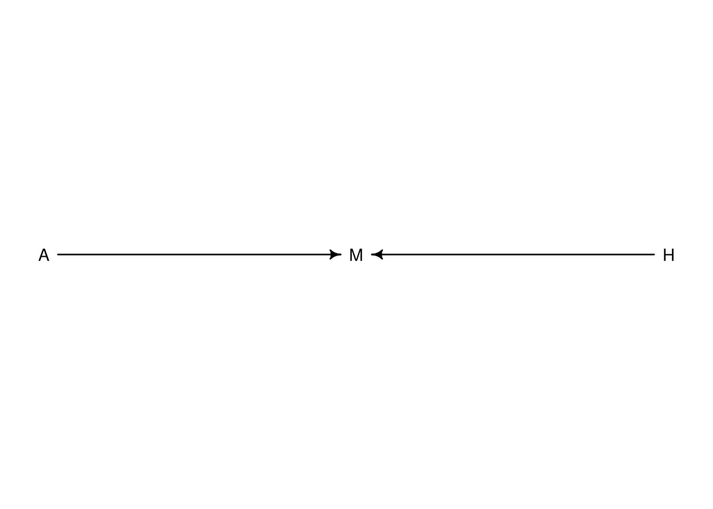

```r
dag <- dagitty::dagitty("dag{A -> M <- H}")
dagitty::coordinates(dag) <- list(x = c(A = 0, M = 0.5, H = 1), y = c(A = 0, M = 0, H = 0))
drawdag(dag)
```

Because married status is a collider, by including all three variables in `m6.9` we condition on marriage which creates a statistical relationship between age and happiness, even though such a causal relationship does not exist. This means that in `m6.9` if we increase age, we make people more happy, and hence the predictability of happiness increases in model `m6.9` compares to model `m6.10`, thus generating a lower WAIC. However, this is not an accurate reflection of underlying causality.

### 7H5

Lets load and standardize the fox data:

```r
library(dplyr)

data(foxes)
d <- foxes

d <- d |>
  dplyr::mutate(across(c(avgfood, groupsize, area, weight), standardize))
```

Let’s create the five models:

```r
fox1 <- quap(
  alist(
    weight ~ dnorm(mu, sigma),
    mu <- a + b[1]*avgfood + b[2]*groupsize + b[3]*area,
    a ~ dnorm(0, 0.2),
    b ~ dnorm(0, 0.5),
    sigma ~ dexp(1)
  ),
  data = d,
  start = list(b = c(0, 0, 0))
)

fox2 <- quap(
  alist(
    weight ~ dnorm(mu, sigma),
    mu <- a + b[1]*avgfood + b[2]*groupsize,
    a ~ dnorm(0, 0.2),
    b ~ dnorm(0, 0.5),
    sigma ~ dexp(1)
  ),
  data = d,
  start = list(b = c(0, 0))
)

fox3 <- quap(
  alist(
    weight ~ dnorm(mu, sigma),
    mu <- a + b[1]*groupsize + b[2]*area,
    a ~ dnorm(0, 0.2),
    b ~ dnorm(0, 0.5),
    sigma ~ dexp(1)
  ),
  data = d,
  start = list(b = c(0, 0))
)

fox4 <- quap(
  alist(
    weight ~ dnorm(mu, sigma),
    mu <- a + b[1]*avgfood,
    a ~ dnorm(0, 0.2),
    b ~ dnorm(0, 0.5),
    sigma ~ dexp(1)
  ),
  data = d
)

fox5 <- quap(
  alist(
    weight ~ dnorm(mu, sigma),
    mu <- a + b[1]*area,
    a ~ dnorm(0, 0.2),
    b ~ dnorm(0, 0.5),
    sigma ~ dexp(1)
  ),
  data = d
)
```

Now let’s compare WAIC scores:

```r
compare(fox1, fox2, fox3, fox4, fox5)
```

```
##          WAIC       SE      dWAIC      dSE    pWAIC      weight
## fox1 323.4887 16.44739  0.0000000       NA 4.987689 0.406255020
## fox2 324.1119 16.29028  0.6232072 3.517435 3.852779 0.297489069
## fox3 324.1576 15.88267  0.6689021 3.098371 3.863483 0.290769258
## fox5 333.4592 13.73725  9.9704938 7.379998 2.507463 0.002778008
## fox4 333.5098 13.76919 10.0210661 7.322244 2.445386 0.002708644
```

Reminding ourselves of the causal model suggested for this problem, we have the following causal pipe:

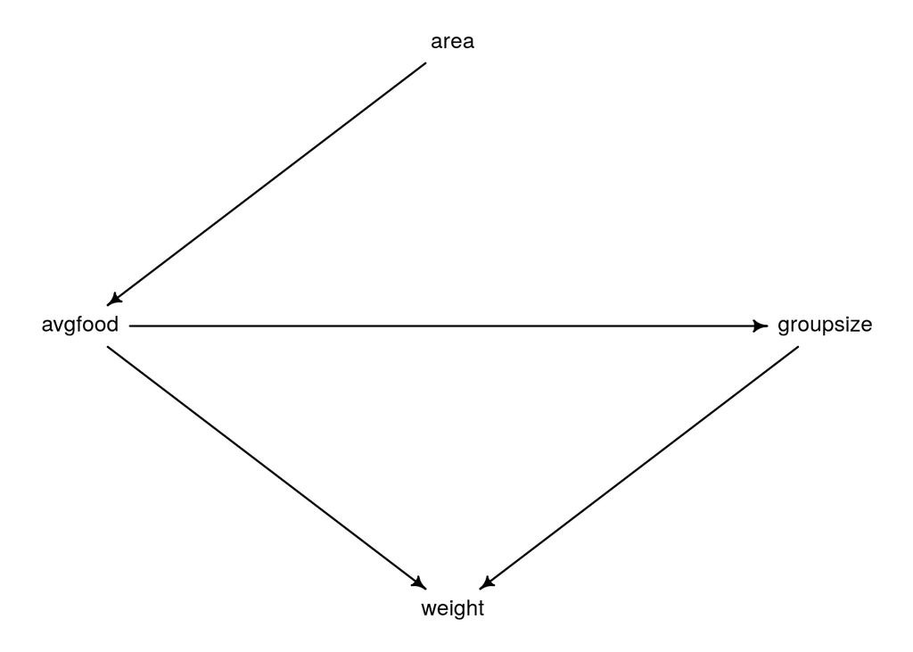

```r
foxdag <- dagitty(
  "dag{
    area -> avgfood -> groupsize -> weight
    avgfood -> weight
  }"
)

coordinates(foxdag) <- list(
  x = c(avgfood = 0, area = 0.5, weight = 0.5, groupsize = 1),
  y = c(weight = 1, avgfood = 0.5, groupsize = 0.5, area = 0)
)

drawdag(foxdag)
```

In models 1 to 3, the `groupsize` variable is included. This means that there is an open backdoor path in our causal model, and we can close it by conditioning on `avgfood`, `area` or both (since there is only one path from `area` to `avgfood`). Hence all three models show similar results.

In models 4 and 5, we do not include `groupsize`, so there are no backdoor paths. Since there is only one path from `area` to `avgfood`, then both models show very similar results.

Models 1 to 3 give a better WAIC because they contain more information.